# Практика · Одноетапні детектори: focal loss і anchor-free

> Лекція: lecture.html · Тест: quiz.html · Домашнє завдання: homework.html

> 🔌 **Мережа не потрібна.** Усі дані зошит генерує формулами, а архітектури `retinanet_resnet50_fpn` і `fcos_resnet50_fpn` збираються офлайн через `weights=None`. Досить `torch`, `torchvision`, `numpy` і `matplotlib`.

> ⏱ Зошит навчає **вісімнадцять** маленьких детекторів (шість настройок × три зерна). Заміряно: **близько трьох хвилин** на чотирьох ядрах без відеокарти — приблизно 9 секунд на одне навчання, 187 секунд на весь зошит.

Що зробимо:

1. порахуємо **дисбаланс** нашої одноетапної голови: скільки позицій позитивні, скільки фонові;
2. подивимось, що з цього виходить, якщо викидати негативні приклади вибіркою **1 : 3**;
3. розберемо **focal loss** по кроках і побудуємо таблицю тлумлення для `p` = 0.9 … 0.1 і γ = 0 … 5;
4. напишемо focal loss **своїми руками** і звіримо з `ops.sigmoid_focal_loss` через `np.allclose`;
5. розкладемо втрату на **фон і предмети** й побачимо, чому легкі приклади забивають градієнт;
6. поміряємо, що робить **ініціалізація зсуву** останнього шару — пару чисел, які вирішують усе;
7. навчимо детектор при **γ = 0, 1, 2, 5** по три зерна й порівняємо `mAP@0.5`;
8. замінимо якірну голову на **anchor-free** і порівняємо параметри, `mAP` і час;
9. перевіримо, що дає **centerness**, і чи справді крайові позиції дають гірші рамки;
10. розберемо `retinanet_resnet50_fpn` і `fcos_resnet50_fpn` і знайдемо, **де саме** вони різняться.

```python
import math
import time
import numpy as np
import torch
import torch.nn as nn
import torch.nn.functional as F
from torchvision.ops import box_iou, nms, sigmoid_focal_loss
import matplotlib.pyplot as plt

# один потік дає і швидкість на маленьких тензорах, і повторюваність чисел:
# під кількома потоками float-суми йдуть в іншому порядку
torch.set_num_threads(1)
torch.manual_seed(0)

print("torch      ", torch.__version__)
print("numpy      ", np.__version__)
print("потоків    ", torch.get_num_threads())
```

```
torch       2.10.0+cpu
numpy       2.5.1
потоків     1
```

## 1 · Датасет: ті самі сцени 64×64

Наскрізний приклад блоку не змінюється: полотно 64 на 64 пікселі, від одного до трьох предметів трьох класів (коло, квадрат, трикутник) радіусом 6-10 пікселів, шум зі стандартним відхиленням 0.12. Рамка кожного предмета рахується **з його маски**, тому вона істинна за побудовою.

Набір трохи менший, ніж у темі 25 — 240 сцен замість 400. Причина проста: ми навчатимемо вісімнадцять мереж замість шести, і час треба на щось витратити.

```python
SIZE = 64                                  # сторона полотна в пікселях
CLASS_NAMES = ["коло", "квадрат", "трикутник"]
CLASS_COUNT = 3
GRID = 8                                   # карта ознак 8×8
STRIDE = SIZE / GRID                       # крок карти: 8 пікселів на клітинку


def shape_mask(kind, center_x, center_y, radius):
    '''Маска однієї фігури на полотні 64×64.'''
    ys, xs = np.mgrid[0:SIZE, 0:SIZE]
    if kind == 0:                                   # коло
        return (xs - center_x) ** 2 + (ys - center_y) ** 2 <= radius * radius
    if kind == 1:                                   # квадрат
        return (np.abs(xs - center_x) <= radius) & (np.abs(ys - center_y) <= radius)
    # трикутник: ширина росте згори вниз
    return ((ys - center_y + radius >= 0) & (ys - center_y <= radius)
            & (np.abs(xs - center_x) <= (ys - center_y + radius) / 2.0))


def make_scene(rng, min_objects=1, max_objects=4, min_radius=6, max_radius=11):
    '''Одна сцена: картинка, рамки з масок, мітки класів.'''
    image = np.zeros((SIZE, SIZE), np.float32)
    boxes, labels = [], []
    for _ in range(int(rng.integers(min_objects, max_objects))):
        for _attempt in range(40):
            radius = int(rng.integers(min_radius, max_radius))
            center_x = int(rng.integers(radius + 1, SIZE - radius - 1))
            center_y = int(rng.integers(radius + 1, SIZE - radius - 1))
            kind = int(rng.integers(0, 3))
            mask = shape_mask(kind, center_x, center_y, radius)
            ys, xs = np.nonzero(mask)
            # рамка береться з маски: край + 1, як в угоді COCO
            box = [float(xs.min()), float(ys.min()),
                   float(xs.max() + 1), float(ys.max() + 1)]

            # не даємо предметам злипатись більше ніж на 45 % площі нового
            too_close = False
            for previous in boxes:
                overlap_w = max(0, min(box[2], previous[2]) - max(box[0], previous[0]))
                overlap_h = max(0, min(box[3], previous[3]) - max(box[1], previous[1]))
                if overlap_w * overlap_h > 0.45 * (box[2] - box[0]) * (box[3] - box[1]):
                    too_close = True
                    break
            if too_close:
                continue

            image[mask] = 1.0
            boxes.append(box)
            labels.append(kind)
            break
    image = np.clip(image + rng.normal(0, 0.12, (SIZE, SIZE)).astype(np.float32), 0, 1)
    return image, np.array(boxes, np.float32), np.array(labels, np.int64)


def make_dataset(seed, count):
    rng = np.random.default_rng(seed)
    return [make_scene(rng) for _ in range(count)]


started = time.time()
train_set = make_dataset(42, 240)
test_set = make_dataset(7, 120)
true_box_count = sum(len(scene[1]) for scene in test_set)

# істина в зручному вигляді: список пар (рамки, мітки) по сценах
ground_truth = [(torch.from_numpy(scene[1]), torch.from_numpy(scene[2]))
                for scene in test_set]

print("згенеровано за %.2f с" % (time.time() - started))
print("навчальних сцен %d, перевірних %d" % (len(train_set), len(test_set)))
print("істинних рамок у перевірному наборі: %d" % true_box_count)
print("предметів на сцену в середньому: %.2f"
      % (sum(len(s[1]) for s in train_set) / len(train_set)))
```

```
згенеровано за 0.14 с
навчальних сцен 240, перевірних 120
істинних рамок у перевірному наборі: 247
предметів на сцену в середньому: 2.09
```

## 2 · Дисбаланс: скільки позицій дивиться одноетапна голова

Наша голова стоїть на карті ознак 8 на 8 і в кожній клітинці має **три квадратні якорі** розміром 12, 18 і 26 пікселів. Розміри взяті під наші предмети: рамка фігури радіусом 6-10 пікселів має сторону приблизно від 12 до 21 пікселя.

Правило зіставлення — те саме, що в темі 24, лише пороги мʼякші: якір позитивний при `IoU ≥ 0.5`, негативний при `IoU < 0.4`, між ними ігнорується. Плюс рятівне правило: найкращий якір кожної істинної рамки позитивний завжди.

```python
ANCHOR_SIZES = (12.0, 18.0, 26.0)          # сторони квадратних якорів у пікселях
ANCHOR_COUNT = len(ANCHOR_SIZES)


def build_anchors():
    '''Три квадратні якорі в центрі кожної клітинки карти 8×8.'''
    out = []
    for row in range(GRID):
        for col in range(GRID):
            center_x = (col + 0.5) * STRIDE
            center_y = (row + 0.5) * STRIDE
            for size in ANCHOR_SIZES:
                out.append([center_x - size / 2, center_y - size / 2,
                            center_x + size / 2, center_y + size / 2])
    return torch.tensor(out, dtype=torch.float32)


ANCHORS = build_anchors()


def anchor_targets(boxes, labels, positive_iou=0.5, negative_iou=0.4):
    '''Стан кожного якоря: 1 позитивний, 0 фон, -1 ігнорується.'''
    total = ANCHORS.shape[0]
    state = torch.zeros(total, dtype=torch.long)
    class_id = torch.full((total,), -1, dtype=torch.long)
    matched = torch.zeros(total, 4)
    if len(boxes) == 0:
        return state, class_id, matched

    truth = torch.from_numpy(boxes)
    overlaps = box_iou(ANCHORS, truth)                 # (якорів, істин)
    best_iou, best_truth = overlaps.max(dim=1)
    state[(best_iou >= negative_iou) & (best_iou < positive_iou)] = -1
    state[best_iou >= positive_iou] = 1

    # рятівне правило: найкращий якір кожної істини стає позитивним попри поріг
    for truth_index in range(truth.shape[0]):
        anchor_index = int(overlaps[:, truth_index].argmax().item())
        state[anchor_index] = 1
        best_truth[anchor_index] = truth_index

    positive = state == 1
    class_id[positive] = torch.from_numpy(labels)[best_truth[positive]]
    matched[positive] = truth[best_truth[positive]]
    return state, class_id, matched


positive_total, ignored_total = 0, 0
for _image, boxes, labels in train_set:
    state, _class_id, _matched = anchor_targets(boxes, labels)
    positive_total += int((state == 1).sum())
    ignored_total += int((state == -1).sum())

decisions = ANCHORS.shape[0] * CLASS_COUNT
positive_per_scene = positive_total / len(train_set)

print("якорів на сцену:                     %d = 64 клітинки × %d розміри"
      % (ANCHORS.shape[0], ANCHOR_COUNT))
print("бінарних рішень «клас чи не клас»:   %d = %d якорів × %d класи"
      % (decisions, ANCHORS.shape[0], CLASS_COUNT))
print()
print("позитивних якорів на сцену:          %.2f (%.3f %% від усіх якорів)"
      % (positive_per_scene, 100 * positive_per_scene / ANCHORS.shape[0]))
print("ігнорованих якорів на сцену:         %.2f"
      % (ignored_total / len(train_set)))
print("позитивних рішень:                   %.3f %%"
      % (100 * positive_per_scene / decisions))
print("на один позитивний припадає:         %.0f негативних"
      % ((decisions - positive_per_scene) / positive_per_scene))
```

```
якорів на сцену:                     192 = 64 клітинки × 3 розміри
бінарних рішень «клас чи не клас»:   576 = 192 якорів × 3 класи

позитивних якорів на сцену:          4.05 (2.109 % від усіх якорів)
ігнорованих якорів на сцену:         4.31
позитивних рішень:                   0.703 %
на один позитивний припадає:         141 негативних
```

### Милиця перша: викидати негативні приклади

До focal loss дисбаланс лікували вибіркою. Faster R-CNN бере збалансований мінібатч якорів, SSD залишає найважчі негативні у співвідношенні **1 : 3** до позитивних (це зветься **hard negative mining**, жорсткий добір негативних прикладів).

Порахуємо, чого це коштує на нашій сцені.

```python
kept_negatives = 3 * positive_per_scene
kept_total = positive_per_scene + kept_negatives

print("рішень на сцені всього:              %d" % decisions)
print("позитивних:                          %.2f" % positive_per_scene)
print("залишається негативних при 1 : 3:    %.2f" % kept_negatives)
print("разом у втраті:                      %.2f з %d" % (kept_total, decisions))
print()
print("викинуто зі сцени:                   %.1f %% усіх рішень"
      % (100 * (decisions - kept_total) / decisions))
print()
print("Тобто на кожному кроці мережа не отримує градієнта майже ні від чого, що є")
print("на картинці. Фон, який вона впевнено вгадала, зникає з навчання зовсім —")
print("а разом із ним і сигнал «так, тут справді нічого немає, тримай цю думку».")
```

```
рішень на сцені всього:              576
позитивних:                          4.05
залишається негативних при 1 : 3:    12.15
разом у втраті:                      16.20 з 576

викинуто зі сцени:                   97.2 % усіх рішень

Тобто на кожному кроці мережа не отримує градієнта майже ні від чого, що є
на картинці. Фон, який вона впевнено вгадала, зникає з навчання зовсім —
а разом із ним і сигнал «так, тут справді нічого немає, тримай цю думку».
```

## 3 · Focal loss по кроках

Звичайна крос-ентропія для одного бінарного рішення — це `−log p`, де `p` — ймовірність, яку модель дала **правильній** відповіді. Якщо модель упевнена й права (`p` близьке до одиниці), логарифм близький до нуля, і приклад майже нічого не додає до втрати. «Майже нічого» — ключове слово: не нуль.

Focal loss домножає крос-ентропію на **множник тлумлення** `(1 − p)^γ`:

`FL = −α (1 − p)^γ · log p`

- `p` — упевненість у правильній відповіді, від 0 до 1;
- `γ` (гамма) — показник степеня; при `γ = 0` формула перетворюється на звичайну крос-ентропію;
- `α` (альфа) — стала вага, різна для предметів і фону.

Побудуємо таблицю руками: що focal loss робить із прикладами різної складності.

```python
confidences = [0.9, 0.7, 0.5, 0.3, 0.1]
gammas = [0.0, 0.5, 1.0, 2.0, 5.0]

header = "   p       CE   " + "".join(["    γ=%-4.1f" % g for g in gammas])
print(header)
print("   " + "-" * (len(header) - 3))
for p in confidences:
    cross_entropy = -math.log(p)
    row = [cross_entropy * (1 - p) ** gamma for gamma in gammas]
    print("  %.1f  %7.4f" % (p, cross_entropy)
          + "".join(["  %8.5f" % value for value in row]))

print()
print("у скільки разів γ=2 тлумить приклад порівняно зі звичайною крос-ентропією:")
for p in confidences:
    cross_entropy = -math.log(p)
    print("   p = %.1f  →  у %7.1f раза тихіше"
          % (p, cross_entropy / (cross_entropy * (1 - p) ** 2)))
print()
print("Легкий приклад (p = 0.9) стає в 100 разів тихішим, важкий (p = 0.1) —")
print("лише в 1.2 раза. Саме це й потрібно: focal loss не викидає легкі приклади,")
print("а стишує їх — плавно, за одним правилом для всіх.")
```

```
   p       CE       γ=0.0     γ=0.5     γ=1.0     γ=2.0     γ=5.0
   ---------------------------------------------------------------
  0.9   0.1054   0.10536   0.03332   0.01054   0.00105   0.00000
  0.7   0.3567   0.35667   0.19536   0.10700   0.03210   0.00087
  0.5   0.6931   0.69315   0.49013   0.34657   0.17329   0.02166
  0.3   1.2040   1.20397   1.00732   0.84278   0.58995   0.20235
  0.1   2.3026   2.30259   2.18442   2.07233   1.86509   1.35965

у скільки разів γ=2 тлумить приклад порівняно зі звичайною крос-ентропією:
   p = 0.9  →  у   100.0 раза тихіше
   p = 0.7  →  у    11.1 раза тихіше
   p = 0.5  →  у     4.0 раза тихіше
   p = 0.3  →  у     2.0 раза тихіше
   p = 0.1  →  у     1.2 раза тихіше

Легкий приклад (p = 0.9) стає в 100 разів тихішим, важкий (p = 0.1) —
лише в 1.2 раза. Саме це й потрібно: focal loss не викидає легкі приклади,
а стишує їх — плавно, за одним правилом для всіх.
```

### Своя реалізація проти бібліотечної

Напишемо формулу двома способами. Перший — буквально з паперу: порахувати `p` через сигмоїду й узяти логарифм. Другий — той самий вираз, але з готовою стійкою крос-ентропією `binary_cross_entropy_with_logits`.

Порівняємо обидва з `torchvision.ops.sigmoid_focal_loss`. Різниця буде повчальною.

```python
def naive_focal_loss(logits, targets, alpha=0.25, gamma=2.0):
    '''Focal loss буквально за формулою: спершу ймовірність, потім логарифм.'''
    p = torch.sigmoid(logits)
    # крос-ентропія: для цілі 1 беремо log p, для цілі 0 — log(1 − p)
    cross_entropy = -(targets * torch.log(p) + (1 - targets) * torch.log(1 - p))
    p_t = p * targets + (1 - p) * (1 - targets)          # упевненість у правильній відповіді
    alpha_t = alpha * targets + (1 - alpha) * (1 - targets)
    return alpha_t * cross_entropy * (1 - p_t) ** gamma


def focal_loss(logits, targets, alpha=0.25, gamma=2.0):
    '''Те саме, але крос-ентропію рахує стійка функція torch.'''
    p = torch.sigmoid(logits)
    cross_entropy = F.binary_cross_entropy_with_logits(logits, targets, reduction="none")
    p_t = p * targets + (1 - p) * (1 - targets)
    alpha_t = alpha * targets + (1 - alpha) * (1 - targets)
    return alpha_t * cross_entropy * (1 - p_t) ** gamma


torch.manual_seed(0)
# логіти детектора легко доходять до ±12: саме там формула й ламається
probe_logits = torch.randn(500, 3) * 3
probe_targets = (torch.rand(500, 3) < 0.1).float()

print("реалізація   найбільше розходження з ops.sigmoid_focal_loss   np.allclose")
for name, our_function in (("наївна", naive_focal_loss), ("стійка", focal_loss)):
    worst = 0.0
    all_close = True
    for alpha in (0.25, 0.5, 0.75):
        for gamma in (0.0, 0.5, 1.0, 2.0, 5.0):
            ours = our_function(probe_logits, probe_targets, alpha, gamma)
            library = sigmoid_focal_loss(probe_logits, probe_targets, alpha, gamma,
                                         reduction="none")
            worst = max(worst, float((ours - library).abs().max()))
            all_close = all_close and np.allclose(ours.numpy(), library.numpy(),
                                                  atol=1e-6)
    print("%-11s  %-49.3g  %s" % (name, worst, all_close))

assert np.allclose(focal_loss(probe_logits, probe_targets, 0.25, 2.0).numpy(),
                   sigmoid_focal_loss(probe_logits, probe_targets, 0.25, 2.0).numpy(),
                   atol=1e-6), "наша focal loss розійшлась із бібліотечною!"
print()
print("✅ стійка реалізація збігається з бібліотечною по всіх 15 комбінаціях α і γ")
```

```
реалізація   найбільше розходження з ops.sigmoid_focal_loss   np.allclose
наївна       0.00489                                            False
стійка       9.54e-07                                           True

✅ стійка реалізація збігається з бібліотечною по всіх 15 комбінаціях α і γ
```

Різниця між двома нашими реалізаціями — не в математиці, а в арифметиці `float32`.

Коли логіт дорівнює 12, сигмоїда дає `p = 0.9999938`. Число `1 − p` — це `6.1 · 10⁻⁶`, і при відніманні майже рівних чисел значущі цифри втрачаються. Логарифм від зіпсованого числа дає похибку близько **0.005** — на кожному з десятків тисяч фонових прикладів. `binary_cross_entropy_with_logits` рахує те саме, не переходячи через `p`, і похибки не має.

Далі всюди беремо стійку версію.

## 4 · Дисбаланс живе не в кількості, а у втраті

Тепер найважливіший замір першої половини теми. Візьмімо **свіжу, ще не навчену** мережу зі звичайною ініціалізацією й порахуймо, скільки втрати дає фон, а скільки — предмети.

Тема 25 робила те саме для YOLO-подібної голови й дістала 92.3 % на фон. У нас голова дивиться на кожен якір окремо, тож подивимось, що вийде тут.

```python
class Body(nn.Module):
    '''Тіло мережі — те саме, що в темах 23 і 25: 64×64 → карта 8×8.'''

    def __init__(self):
        super().__init__()

        def block(in_channels, out_channels):
            return nn.Sequential(
                nn.Conv2d(in_channels, out_channels, 3, padding=1),
                nn.BatchNorm2d(out_channels), nn.ReLU(), nn.MaxPool2d(2))

        self.net = nn.Sequential(
            block(1, 16), block(16, 32), block(32, 64),
            nn.Conv2d(64, 64, 3, padding=1), nn.BatchNorm2d(64), nn.ReLU())

    def forward(self, x):
        return self.net(x)


PRIOR = 0.01                                    # бажана ймовірність предмета на старті
BIAS_INIT = -math.log((1 - PRIOR) / PRIOR)      # зсув, що дає саме таку ймовірність


class AnchorDetector(nn.Module):
    '''Якірна голова RetinaNet-типу: клас на кожен якір і зсув до якоря.'''

    def __init__(self, bias_init=BIAS_INIT):
        super().__init__()
        self.body = Body()
        self.classifier = nn.Conv2d(64, ANCHOR_COUNT * CLASS_COUNT, 3, padding=1)
        self.regressor = nn.Conv2d(64, ANCHOR_COUNT * 4, 3, padding=1)
        # ініціалізація зсуву: див. розділ 5, без неї нічого не працює
        nn.init.constant_(self.classifier.bias, bias_init)

    def forward(self, x):
        features = self.body(x)
        count = x.shape[0]
        logits = self.classifier(features).permute(0, 2, 3, 1).reshape(count, -1,
                                                                      CLASS_COUNT)
        deltas = self.regressor(features).permute(0, 2, 3, 1).reshape(count, -1, 4)
        return logits, deltas


print("зсув для p = %.2f: %.4f" % (PRIOR, BIAS_INIT))
print("перевірка: сигмоїда від нього = %.4f" % float(torch.sigmoid(torch.tensor(BIAS_INIT))))
print()
probe = AnchorDetector()
print("параметрів у мережі:  %d" % sum(p.numel() for p in probe.parameters()))
print("з них у тілі:         %d" % sum(p.numel() for p in probe.body.parameters()))
print("у голові класифікації: %d" % sum(p.numel() for p in probe.classifier.parameters()))
print("у голові регресії:     %d" % sum(p.numel() for p in probe.regressor.parameters()))
```

```
зсув для p = 0.01: -4.5951
перевірка: сигмоїда від нього = 0.0100

параметрів у мережі:  72693
з них у тілі:         60576
у голові класифікації: 5193
у голові регресії:     6924
```

Тепер підготуємо цілі для всього набору — один раз, щоб не рахувати їх у кожному кроці навчання, — і подивимось на розкладку втрати свіжої мережі.

```python
def encode_deltas(anchors, truth):
    '''Зсув від якоря до істинної рамки: два зсуви центра й два логарифми розміру.'''
    anchor_w = anchors[:, 2] - anchors[:, 0]
    anchor_h = anchors[:, 3] - anchors[:, 1]
    anchor_cx = anchors[:, 0] + anchor_w / 2
    anchor_cy = anchors[:, 1] + anchor_h / 2
    truth_w = truth[:, 2] - truth[:, 0]
    truth_h = truth[:, 3] - truth[:, 1]
    truth_cx = truth[:, 0] + truth_w / 2
    truth_cy = truth[:, 1] + truth_h / 2
    return torch.stack([(truth_cx - anchor_cx) / anchor_w,
                        (truth_cy - anchor_cy) / anchor_h,
                        torch.log(truth_w / anchor_w),
                        torch.log(truth_h / anchor_h)], dim=1)


def decode_deltas(anchors, deltas):
    '''Зворотне перетворення: зі зсувів назад у рамку xyxy.'''
    anchor_w = anchors[:, 2] - anchors[:, 0]
    anchor_h = anchors[:, 3] - anchors[:, 1]
    anchor_cx = anchors[:, 0] + anchor_w / 2
    anchor_cy = anchors[:, 1] + anchor_h / 2
    center_x = anchor_cx + deltas[:, 0] * anchor_w
    center_y = anchor_cy + deltas[:, 1] * anchor_h
    width = anchor_w * torch.exp(deltas[:, 2].clamp(max=3.0))
    height = anchor_h * torch.exp(deltas[:, 3].clamp(max=3.0))
    return torch.stack([center_x - width / 2, center_y - height / 2,
                        center_x + width / 2, center_y + height / 2], dim=1)


def pack_anchor(dataset):
    '''Готує тензори всього набору: картинки, маски участі й цілі.'''
    images = torch.from_numpy(np.stack([scene[0] for scene in dataset])[:, None])
    total = ANCHORS.shape[0]
    keep = torch.zeros(len(dataset), total, dtype=torch.bool)
    positive = torch.zeros(len(dataset), total, dtype=torch.bool)
    class_target = torch.zeros(len(dataset), total, CLASS_COUNT)
    delta_target = torch.zeros(len(dataset), total, 4)

    for index, (_image, boxes, labels) in enumerate(dataset):
        state, class_id, matched = anchor_targets(boxes, labels)
        keep[index] = state >= 0                       # ігноровані не входять у втрату
        is_positive = state == 1
        positive[index] = is_positive
        if is_positive.any():
            class_target[index, is_positive, class_id[is_positive]] = 1.0
            delta_target[index, is_positive] = encode_deltas(ANCHORS[is_positive],
                                                             matched[is_positive])
    return images, keep, positive, class_target, delta_target


train_images, train_keep, train_positive, train_class, train_delta = pack_anchor(train_set)
test_images = torch.from_numpy(np.stack([scene[0] for scene in test_set])[:, None])

print("форма цілі класифікації:", tuple(train_class.shape), "= сцен × якорів × класів")
print("позитивних рішень у наборі: %d із %d"
      % (int(train_positive.sum()) , train_class.numel()))
```

```
форма цілі класифікації: (240, 192, 3) = сцен × якорів × класів
позитивних рішень у наборі: 972 із 138240
```

```python
# свіжа мережа з НУЛЬОВИМ зсувом — так робить звичайна ініціалізація torch
torch.manual_seed(0)
fresh = AnchorDetector(bias_init=0.0)
batch_images = train_images[:32]
batch_keep = train_keep[:32]
batch_class = train_class[:32]

with torch.no_grad():
    fresh_logits, _deltas = fresh(batch_images)
    per_element = focal_loss(fresh_logits, batch_class, alpha=0.25, gamma=0.0)

mask = batch_keep.unsqueeze(-1)
background_loss = float((per_element * mask * (1 - batch_class)).sum())
object_loss = float((per_element * mask * batch_class).sum())
total_loss = background_loss + object_loss

print("свіжа мережа, нульовий зсув, звичайна крос-ентропія (γ = 0, α = 0.25)")
print("партія з 32 сцен")
print()
print("  фон:      %9.3f  (%.2f %%)" % (background_loss, 100 * background_loss / total_loss))
print("  предмети: %9.3f  (%.2f %%)" % (object_loss, 100 * object_loss / total_loss))
print("  разом:    %9.3f" % total_loss)
print()
print("Для порівняння, у темі 25 при рівних вагах фон давав 92.3 % втрати.")
print("Тут фон дає %.2f %% — бо голова дивиться на кожен якір і кожен клас окремо."
      % (100 * background_loss / total_loss))
```

```
свіжа мережа, нульовий зсув, звичайна крос-ентропія (γ = 0, α = 0.25)
партія з 32 сцен

  фон:       9286.319  (99.72 %)
  предмети:    26.146  (0.28 %)
  разом:     9312.465

Для порівняння, у темі 25 при рівних вагах фон давав 92.3 % втрати.
Тут фон дає 99.72 % — бо голова дивиться на кожен якір і кожен клас окремо.
```

## 5 · Ініціалізація зсуву останнього шару

Це та деталь RetinaNet, про яку майже не пишуть, а без неї навчання розвалюється на першому ж кроці.

Останній шар голови класифікації має зсув (bias). За замовчуванням `torch` ставить його близько нуля, тож сигмоїда дає ймовірність приблизно `0.5`: **свіжа мережа вважає, що предмет є скрізь**. Кожен із тисяч фонових якорів голосно помиляється, і сума їхніх втрат величезна.

Ліки: поставити зсув так, щоб початкова ймовірність предмета дорівнювала `π = 0.01`.

`зсув = −log((1 − π) ÷ π) = −log(99) = −4.5951`

Поміряймо обидва варіанти на одній і тій самій партії.

```python
def first_step_loss(bias_init, gamma):
    '''Втрата класифікації на самому першому кроці, ще до жодного оновлення ваг.'''
    torch.manual_seed(0)
    model = AnchorDetector(bias_init=bias_init)
    with torch.no_grad():
        logits, _deltas = model(batch_images)
        probability = float(torch.sigmoid(logits).mean())
        per_element = focal_loss(logits, batch_class, alpha=0.25, gamma=gamma)
        background = float((per_element * mask * (1 - batch_class)).sum())
        objects = float((per_element * mask * batch_class).sum())
    # ділимо на кількість позитивних — так нормують втрату в RetinaNet
    positives = max(1, int(train_positive[:32].sum()))
    return ((background + objects) / positives, probability,
            100 * background / (background + objects))


print("зсув        γ    p(предмет) на старті   втрата на позитивний   частка фону")
print("-" * 74)
numbers = {}
for name, bias in (("нульовий", 0.0), ("π = 0.01", BIAS_INIT)):
    for gamma in (0.0, 2.0):
        loss, probability, share = first_step_loss(bias, gamma)
        numbers[(name, gamma)] = loss
        print("%-10s  %.0f    %6.4f                %10.3f            %6.2f %%"
              % (name, gamma, probability, loss, share))

print()
print("крос-ентропія (γ=0):  %8.2f  →  %6.2f   у %.1f раза менше"
      % (numbers[("нульовий", 0.0)], numbers[("π = 0.01", 0.0)],
         numbers[("нульовий", 0.0)] / numbers[("π = 0.01", 0.0)]))
print("focal loss (γ=2):     %8.2f  →  %6.2f   у %.1f раза менше"
      % (numbers[("нульовий", 2.0)], numbers[("π = 0.01", 2.0)],
         numbers[("нульовий", 2.0)] / numbers[("π = 0.01", 2.0)]))
print()
print("Це не про красу числа. Втрата в тридцять разів більша означає градієнт")
print("у тридцять разів більший — і перший же крок оптимізатора зриває ваги")
print("в бік «мовчи скрізь», звідки мережа може й не повернутись.")
print()

# та сама втрата, порахована формулою: усі логіти дорівнюють зсуву, тож p однакове
kept_decisions = int(batch_keep.sum()) * CLASS_COUNT
positive_decisions = int((batch_class * batch_keep.unsqueeze(-1)).sum())
negative_decisions = kept_decisions - positive_decisions
print("у партії з 32 сцен беруть участь %d рішень:" % kept_decisions)
print("   позитивних %d, фонових %d" % (positive_decisions, negative_decisions))
print()


def analytic_first_step(prior, gamma, alpha=0.25):
    '''Втрата першого кроку за формулою, якщо всі логіти дорівнюють зсуву.'''
    background = negative_decisions * (1 - alpha) * prior ** gamma * -math.log(1 - prior)
    objects = positive_decisions * alpha * (1 - prior) ** gamma * -math.log(prior)
    return (background + objects) / positive_decisions, 100 * background / (background + objects)


print("   π      γ    формула   заміряно   частка фону за формулою")
for prior, gamma, measured in ((0.5, 0.0, numbers[("нульовий", 0.0)]),
                               (0.01, 0.0, numbers[("π = 0.01", 0.0)]),
                               (0.5, 2.0, numbers[("нульовий", 2.0)]),
                               (0.01, 2.0, numbers[("π = 0.01", 2.0)])):
    value, share = analytic_first_step(prior, gamma)
    print("  %.2f    %.0f   %8.2f   %8.2f        %6.2f %%"
          % (prior, gamma, value, measured, share))
print()
print("Формула збігається із заміром у межах кількох відсотків: розбіжність від того,")
print("що справжні логіти не однакові, а трохи розкидані навколо зсуву.")
```

```
зсув        γ    p(предмет) на старті   втрата на позитивний   частка фону
--------------------------------------------------------------------------
нульовий    0    0.4918                    72.190             99.72 %
```

```
нульовий    2    0.4918                    19.698             99.60 %
```

```
π = 0.01    0    0.0103                     2.255             47.83 %
```

```
π = 0.01    2    0.0103                     1.152              0.02 %

крос-ентропія (γ=0):     72.19  →    2.25   у 32.0 раза менше
focal loss (γ=2):        19.70  →    1.15   у 17.1 раза менше

Це не про красу числа. Втрата в тридцять разів більша означає градієнт
у тридцять разів більший — і перший же крок оптимізатора зриває ваги
в бік «мовчи скрізь», звідки мережа може й не повернутись.

у партії з 32 сцен беруть участь 17958 рішень:
   позитивних 129, фонових 17829

   π      γ    формула   заміряно   частка фону за формулою
  0.50    0      72.02      72.19         99.76 %
  0.01    0       2.19       2.25         47.50 %
  0.50    2      18.01      19.70         99.76 %
  0.01    2       1.13       1.15          0.01 %

Формула збігається із заміром у межах кількох відсотків: розбіжність від того,
що справжні логіти не однакові, а трохи розкидані навколо зсуву.
```

## 6 · Навчання: що робить γ

Тепер головний замір теми. Навчимо той самий детектор при `γ` = 0, 1, 2 і 5, кожен — **із трьох зерен**, і подивимось на `mAP@0.5`.

`γ = 0` — це звичайна крос-ентропія з ваговим коефіцієнтом `α`, тобто focal loss без власне focal-частини. Її ми й беремо за точку відліку.

⏱ Ця клітинка йде близько **двох хвилин**: дванадцять навчань приблизно по 9 секунд.

```python
def anchor_loss(model_output, keep, positive, class_target, delta_target,
                gamma, alpha=0.25):
    '''Втрата якірного детектора: focal по класах + smooth L1 по рамках.'''
    logits, deltas = model_output
    per_element = focal_loss(logits, class_target, alpha, gamma)
    classification = (per_element * keep.unsqueeze(-1)).sum()
    if positive.any():
        regression = F.smooth_l1_loss(deltas[positive], delta_target[positive],
                                      reduction="sum")
    else:
        regression = logits.sum() * 0
    # нормування на кількість позитивних — так робить RetinaNet
    positives = max(1, int(positive.sum().item()))
    return (classification + regression) / positives


def train_anchor(seed, gamma, epochs=12, learning_rate=3e-3):
    '''Навчає якірний детектор з нуля. Зерно керує вагами й порядком партій.'''
    torch.manual_seed(seed)
    model = AnchorDetector()
    optimizer = torch.optim.AdamW(model.parameters(), lr=learning_rate)
    started = time.time()
    model.train()
    for _epoch in range(epochs):
        order = torch.randperm(len(train_images))
        for start in range(0, len(train_images), 32):
            batch = order[start:start + 32]
            loss = anchor_loss(model(train_images[batch]), train_keep[batch],
                               train_positive[batch], train_class[batch],
                               train_delta[batch], gamma)
            optimizer.zero_grad()
            loss.backward()
            optimizer.step()
    return model, time.time() - started


@torch.no_grad()
def predict_anchor(model, images):
    '''Вихід мережі → списки (рамки, оцінки, класи) по сценах.'''
    model.eval()
    logits, deltas = model(images)
    probabilities = torch.sigmoid(logits)
    results = []
    for index in range(images.shape[0]):
        boxes = decode_deltas(ANCHORS, deltas[index])
        score, class_id = probabilities[index].max(dim=1)
        results.append((boxes, score, class_id))
    return results


print("готово: одне навчання — 12 епох по 240 сцен, AdamW, lr = 3e-3")
```

```
готово: одне навчання — 12 епох по 240 сцен, AdamW, lr = 3e-3
```

```python
def greedy_match(boxes, scores, truth_boxes, iou_threshold):
    '''Жадібне зіставлення за спаданням оцінки — те саме, що в темі 23.'''
    order = torch.argsort(scores, descending=True)
    taken = [False] * len(truth_boxes)
    hits = torch.zeros(len(order))
    if len(truth_boxes) and len(order):
        overlaps = box_iou(boxes[order], truth_boxes)
        for position in range(len(order)):
            best_value, best_index = -1.0, -1
            for truth_index in range(len(truth_boxes)):
                if taken[truth_index]:
                    continue
                if overlaps[position, truth_index].item() > best_value:
                    best_value = overlaps[position, truth_index].item()
                    best_index = truth_index
            if best_index >= 0 and best_value >= iou_threshold:
                taken[best_index] = True
                hits[position] = 1.0
    return scores[order], hits


def average_precision(scores, hits, truth_count):
    '''AP як площа під огинальною кривої точність-повнота.'''
    order = torch.argsort(scores, descending=True)
    ordered_hits = hits[order]
    running_hits = torch.cumsum(ordered_hits, 0)
    running_misses = torch.cumsum(1 - ordered_hits, 0)
    precision = running_hits / (running_hits + running_misses)
    recall = running_hits / truth_count

    envelope = precision.clone()
    for i in range(len(envelope) - 2, -1, -1):
        envelope[i] = max(envelope[i].item(), envelope[i + 1].item())

    area, previous_recall = 0.0, 0.0
    for i in range(len(envelope)):
        area += (recall[i].item() - previous_recall) * envelope[i].item()
        previous_recall = recall[i].item()
    return area


def mean_average_precision(predictions, iou_threshold=0.5, nms_threshold=0.5,
                           score_floor=1e-3):
    '''mAP при одному порозі IoU: середнє AP по трьох класах.'''
    values = []
    for class_index in range(CLASS_COUNT):
        score_parts, hit_parts, truth_count = [], [], 0
        for (boxes, scores, labels), (truth_boxes, truth_labels) in zip(predictions,
                                                                        ground_truth):
            chosen = (scores >= score_floor) & (labels == class_index)
            picked_boxes, picked_scores = boxes[chosen], scores[chosen]
            if len(picked_boxes):
                keep = nms(picked_boxes, picked_scores, nms_threshold)
                picked_boxes, picked_scores = picked_boxes[keep], picked_scores[keep]
            this_truth = truth_boxes[truth_labels == class_index]
            truth_count += len(this_truth)
            ordered, hits = greedy_match(picked_boxes, picked_scores, this_truth,
                                         iou_threshold)
            score_parts.append(ordered)
            hit_parts.append(hits)
        values.append(average_precision(torch.cat(score_parts), torch.cat(hit_parts),
                                        max(1, truth_count)))
    return float(np.mean(values)), values


gamma_scores = {}
gamma_models = {}
training_seconds = []

for gamma in (0.0, 1.0, 2.0, 5.0):
    values = []
    for seed in (0, 1, 2):
        model, seconds = train_anchor(seed, gamma)
        training_seconds.append(seconds)
        value, _per_class = mean_average_precision(predict_anchor(model, test_images))
        values.append(value)
        if seed == 0:
            gamma_models[gamma] = model
        print("  γ = %.0f  зерно %d:  %4.1f с   mAP@0.5 = %.4f" % (gamma, seed, seconds, value))
    gamma_scores[gamma] = values
    print("  γ = %.0f  середнє %.4f, розкид %.4f"
          % (gamma, float(np.mean(values)), max(values) - min(values)))
    print()
```

```
  γ = 0  зерно 0:  12.3 с   mAP@0.5 = 0.8067
```

```
  γ = 0  зерно 1:   9.8 с   mAP@0.5 = 0.6646
```

```
  γ = 0  зерно 2:   9.0 с   mAP@0.5 = 0.7935
  γ = 0  середнє 0.7549, розкид 0.1420
```

```
  γ = 1  зерно 0:   9.8 с   mAP@0.5 = 0.7988
```

```
  γ = 1  зерно 1:   9.9 с   mAP@0.5 = 0.6984
```

```
  γ = 1  зерно 2:   9.1 с   mAP@0.5 = 0.8479
  γ = 1  середнє 0.7817, розкид 0.1495
```

```
  γ = 2  зерно 0:   9.6 с   mAP@0.5 = 0.8805
```

```
  γ = 2  зерно 1:   9.6 с   mAP@0.5 = 0.8361
```

```
  γ = 2  зерно 2:   9.4 с   mAP@0.5 = 0.8662
  γ = 2  середнє 0.8610, розкид 0.0444
```

```
  γ = 5  зерно 0:   9.0 с   mAP@0.5 = 0.5930
```

```
  γ = 5  зерно 1:   9.5 с   mAP@0.5 = 0.5970
```

```
  γ = 5  зерно 2:   9.8 с   mAP@0.5 = 0.5069
  γ = 5  середнє 0.5656, розкид 0.0902
```

```python
print("  γ    зерно 0   зерно 1   зерно 2   середнє   розкид")
print("  " + "-" * 52)
for gamma in (0.0, 1.0, 2.0, 5.0):
    values = gamma_scores[gamma]
    print("  %.0f    %.4f    %.4f    %.4f    %.4f    %.4f"
          % (gamma, values[0], values[1], values[2],
             float(np.mean(values)), max(values) - min(values)))

best_gamma = max(gamma_scores, key=lambda g: float(np.mean(gamma_scores[g])))
gain = float(np.mean(gamma_scores[best_gamma])) - float(np.mean(gamma_scores[0.0]))
loss_at_five = float(np.mean(gamma_scores[best_gamma])) - float(np.mean(gamma_scores[5.0]))
biggest_spread = max(max(v) - min(v) for v in gamma_scores.values())

print()
print("найкраще γ = %.0f, середній mAP %.4f"
      % (best_gamma, np.mean(gamma_scores[best_gamma])))
print("виграш над звичайною крос-ентропією (γ = 0):  %+.4f" % gain)
print("програш при надто великому γ = 5:             %+.4f" % -loss_at_five)
print("найбільший розкид усередині однієї настройки:  %.4f" % biggest_spread)
print()

# порівняння середніх при великому розкиді ненадійне, тому дивимось на крайні зерна
worst_best = min(gamma_scores[best_gamma])
best_zero = max(gamma_scores[0.0])
print("найгірше зерно γ = %.0f:  %.4f" % (best_gamma, worst_best))
print("найкраще зерно γ = 0:   %.4f" % best_zero)
if worst_best > best_zero:
    print("→ УСІ три зерна γ = %.0f кращі за УСІ три зерна γ = 0." % best_gamma)
    print("  Це сильніше твердження, ніж різниця середніх: воно не залежить від")
    print("  того, наскільки великий розкид усередині кожної настройки.")
else:
    print("→ Купи зерен перетинаються: різницю на трьох зернах не впіймано.")
print()
print("Виграш γ = 2 над γ = 0 (%+.4f) сам по собі менший за розкид γ = 0 (%.4f)"
      % (gain, max(gamma_scores[0.0]) - min(gamma_scores[0.0])))
print("і без порівняння крайніх зерен його не варто було б називати справжнім.")
print("А от провал при γ = 5 (%+.4f) більший за будь-який розкид у таблиці —"
      % -loss_at_five)
print("тут сумніватись нема в чому: занадто сильне тлумлення глушить і корисні")
print("приклади теж.")
print()
print("Окремо подивись на розкид: при γ = 0 він %.4f, при γ = 2 — %.4f."
      % (max(gamma_scores[0.0]) - min(gamma_scores[0.0]),
         max(gamma_scores[2.0]) - min(gamma_scores[2.0])))
print("Focal loss не лише піднімає середнє, а й робить навчання передбачуванішим.")
```

```
  γ    зерно 0   зерно 1   зерно 2   середнє   розкид
  ----------------------------------------------------
  0    0.8067    0.6646    0.7935    0.7549    0.1420
  1    0.7988    0.6984    0.8479    0.7817    0.1495
  2    0.8805    0.8361    0.8662    0.8610    0.0444
  5    0.5930    0.5970    0.5069    0.5656    0.0902

найкраще γ = 2, середній mAP 0.8610
виграш над звичайною крос-ентропією (γ = 0):  +0.1060
програш при надто великому γ = 5:             -0.2953
найбільший розкид усередині однієї настройки:  0.1495

найгірше зерно γ = 2:  0.8361
найкраще зерно γ = 0:   0.8067
→ УСІ три зерна γ = 2 кращі за УСІ три зерна γ = 0.
  Це сильніше твердження, ніж різниця середніх: воно не залежить від
  того, наскільки великий розкид усередині кожної настройки.

Виграш γ = 2 над γ = 0 (+0.1060) сам по собі менший за розкид γ = 0 (0.1420)
і без порівняння крайніх зерен його не варто було б називати справжнім.
А от провал при γ = 5 (-0.2953) більший за будь-який розкид у таблиці —
тут сумніватись нема в чому: занадто сильне тлумлення глушить і корисні
приклади теж.

Окремо подивись на розкид: при γ = 0 він 0.1420, при γ = 2 — 0.0444.
Focal loss не лише піднімає середнє, а й робить навчання передбачуванішим.
```

### Хто саме дає втрату після навчання

Тепер повернімось до заміру з розділу 4, але на **навченій** мережі. Розділимо всі рішення на три купи:

- **позитивні** — там, де предмет справді є;
- **важкі негативні** — фон, у якому мережа підозрює предмет (`p ≥ 0.1`);
- **легкі негативні** — фон, у якому мережа впевнена (`p < 0.1`).

І подивимось, скільки втрати дає кожна купа при різних `γ`.

```python
reference = gamma_models[2.0]
reference.eval()
with torch.no_grad():
    logits, _deltas = reference(batch_images)
    probability = torch.sigmoid(logits)

keep_mask = batch_keep.unsqueeze(-1).expand_as(logits)
positive_mask = (batch_class > 0.5) & keep_mask
negative_mask = (batch_class < 0.5) & keep_mask
easy_mask = negative_mask & (probability < 0.1)
hard_mask = negative_mask & (probability >= 0.1)

print("на партії з 32 сцен:")
print("  позитивних рішень:        %6d" % int(positive_mask.sum()))
print("  важких негативних:        %6d" % int(hard_mask.sum()))
print("  легких негативних:        %6d" % int(easy_mask.sum()))
print()
print("   γ    позитивні        важкі негат.     легкі негат.")
print("  " + "-" * 56)
contribution = {}
for gamma in (0.0, 0.5, 1.0, 2.0, 5.0):
    per_element = focal_loss(logits, batch_class, alpha=0.25, gamma=gamma)
    parts = [float((per_element * positive_mask).sum()),
             float((per_element * hard_mask).sum()),
             float((per_element * easy_mask).sum())]
    total = sum(parts)
    contribution[gamma] = [100 * p / total for p in parts]
    print("  %.1f   %7.3f (%4.1f %%)  %7.3f (%4.1f %%)  %7.3f (%4.1f %%)"
          % (gamma, parts[0], 100 * parts[0] / total,
             parts[1], 100 * parts[1] / total,
             parts[2], 100 * parts[2] / total))

print()
print("Легких негативних у %d разів більше за позитивні, і при звичайній"
      % (int(easy_mask.sum()) // max(1, int(positive_mask.sum()))))
print("крос-ентропії вони дають %.1f %% усієї втрати — більше за всі предмети разом."
      % contribution[0.0][2])
print("При γ = 2 їхня частка падає до %.1f %%, а частка предметів росте з %.1f %% до %.1f %%."
      % (contribution[2.0][2], contribution[0.0][0], contribution[2.0][0]))
```

```
на партії з 32 сцен:
  позитивних рішень:           129
  важких негативних:           288
  легких негативних:         17541

   γ    позитивні        важкі негат.     легкі негат.
  --------------------------------------------------------
  0.0    26.473 (15.8 %)   44.169 (26.4 %)   96.463 (57.7 %)
  0.5    20.719 (36.7 %)   20.481 (36.2 %)   15.330 (27.1 %)
  1.0    16.613 (55.8 %)   10.037 (33.7 %)    3.097 (10.4 %)
  2.0    11.281 (78.9 %)    2.837 (19.8 %)    0.178 ( 1.2 %)
  5.0     4.689 (96.6 %)    0.166 ( 3.4 %)    0.000 ( 0.0 %)

Легких негативних у 135 разів більше за позитивні, і при звичайній
крос-ентропії вони дають 57.7 % усієї втрати — більше за всі предмети разом.
При γ = 2 їхня частка падає до 1.2 %, а частка предметів росте з 15.8 % до 78.9 %.
```

## 7 · Anchor-free: прибираємо якорі

Якірна голова тримає три припущення, які треба вгадувати наперед: **скільки** якорів, **яких розмірів** і **яких пропорцій**, плюс два пороги IoU для зіставлення. Тема 24 показала, чим це коштує: з девʼяти варіантів якоря на її сцені працювали два, а 28.3 % істинних рамок не мали жодного якоря з IoU понад 0.7.

Anchor-free голова у стилі **FCOS** робить інакше. У кожній позиції карти ознак вона передбачає **чотири відстані** — до лівого, верхнього, правого й нижнього краю рамки. Заготовок немає взагалі, вгадувати нічого.

Правило зіставлення теж простіше: позиція позитивна, якщо її центр **усередині** істинної рамки. Якщо всередині кількох — береться рамка з найменшою площею.

```python
def build_points():
    '''Центр кожної клітинки карти 8×8 у пікселях вхідного зображення.'''
    out = []
    for row in range(GRID):
        for col in range(GRID):
            out.append([(col + 0.5) * STRIDE, (row + 0.5) * STRIDE])
    return torch.tensor(out, dtype=torch.float32)


POINTS = build_points()


def free_targets(boxes, labels):
    '''Ціль anchor-free: позиція позитивна, якщо вона всередині рамки.'''
    total = POINTS.shape[0]
    positive = torch.zeros(total, dtype=torch.bool)
    class_id = torch.full((total,), -1, dtype=torch.long)
    distances = torch.zeros(total, 4)
    if len(boxes) == 0:
        return positive, class_id, distances

    truth = torch.from_numpy(boxes)
    areas = (truth[:, 2] - truth[:, 0]) * (truth[:, 3] - truth[:, 1])
    point_x = POINTS[:, 0:1]
    point_y = POINTS[:, 1:2]
    left = point_x - truth[:, 0]
    top = point_y - truth[:, 1]
    right = truth[:, 2] - point_x
    bottom = truth[:, 3] - point_y

    inside = (left > 0) & (top > 0) & (right > 0) & (bottom > 0)
    # серед рамок, що містять точку, беремо найменшу за площею
    area_or_infinity = torch.where(inside, areas.expand_as(inside),
                                   torch.full_like(inside, float("inf"),
                                                   dtype=torch.float32))
    smallest_area, chosen = area_or_infinity.min(dim=1)
    positive = torch.isfinite(smallest_area)

    index = torch.arange(total)
    stacked = torch.stack([left[index, chosen], top[index, chosen],
                           right[index, chosen], bottom[index, chosen]], dim=1)
    distances[positive] = stacked[positive] / STRIDE     # ділимо на крок карти
    class_id[positive] = torch.from_numpy(labels)[chosen[positive]]
    return positive, class_id, distances


def centerness_target(distances):
    '''Наскільки позиція близька до центра рамки: 1 у центрі, 0 на краю.'''
    left, top, right, bottom = distances.unbind(dim=1)
    horizontal = torch.min(left, right) / torch.max(left, right).clamp(min=1e-6)
    vertical = torch.min(top, bottom) / torch.max(top, bottom).clamp(min=1e-6)
    return torch.sqrt((horizontal * vertical).clamp(min=0))


# приклад руками: рамка 20×20 з центром у (30, 30), позиція в (28, 30)
example_box = torch.tensor([[20.0, 20.0, 40.0, 40.0]])
for offset in (0, 2, 4, 6, 8):
    left, right = 10.0 + offset, 10.0 - offset
    top, bottom = 10.0, 10.0
    value = math.sqrt((min(left, right) / max(left, right))
                      * (min(top, bottom) / max(top, bottom)))
    print("зсув %d px від центра: l = %4.1f, r = %4.1f  →  centerness = %.3f"
          % (offset, left, right, value))
```

```
зсув 0 px від центра: l = 10.0, r = 10.0  →  centerness = 1.000
зсув 2 px від центра: l = 12.0, r =  8.0  →  centerness = 0.816
зсув 4 px від центра: l = 14.0, r =  6.0  →  centerness = 0.655
зсув 6 px від центра: l = 16.0, r =  4.0  →  centerness = 0.500
зсув 8 px від центра: l = 18.0, r =  2.0  →  centerness = 0.333
```

```python
class FreeDetector(nn.Module):
    '''Anchor-free голова: класи, чотири відстані й (за бажанням) centerness.'''

    def __init__(self, use_centerness=True, bias_init=BIAS_INIT):
        super().__init__()
        self.body = Body()
        self.classifier = nn.Conv2d(64, CLASS_COUNT, 3, padding=1)
        self.regressor = nn.Conv2d(64, 4, 3, padding=1)
        self.centerness = nn.Conv2d(64, 1, 3, padding=1) if use_centerness else None
        nn.init.constant_(self.classifier.bias, bias_init)

    def forward(self, x):
        features = self.body(x)
        count = x.shape[0]
        logits = self.classifier(features).permute(0, 2, 3, 1).reshape(count, -1,
                                                                      CLASS_COUNT)
        # відстані невідʼємні за змістом, тому пропускаємо їх крізь ReLU
        distances = F.relu(self.regressor(features)).permute(0, 2, 3, 1).reshape(count,
                                                                                 -1, 4)
        if self.centerness is None:
            return logits, distances, None
        center = self.centerness(features).permute(0, 2, 3, 1).reshape(count, -1)
        return logits, distances, center


def pack_free(dataset):
    images = torch.from_numpy(np.stack([scene[0] for scene in dataset])[:, None])
    total = POINTS.shape[0]
    positive = torch.zeros(len(dataset), total, dtype=torch.bool)
    class_target = torch.zeros(len(dataset), total, CLASS_COUNT)
    distance_target = torch.zeros(len(dataset), total, 4)
    center_target = torch.zeros(len(dataset), total)

    for index, (_image, boxes, labels) in enumerate(dataset):
        is_positive, class_id, distances = free_targets(boxes, labels)
        positive[index] = is_positive
        if is_positive.any():
            class_target[index, is_positive, class_id[is_positive]] = 1.0
            distance_target[index, is_positive] = distances[is_positive]
            center_target[index, is_positive] = centerness_target(distances[is_positive])
    return images, positive, class_target, distance_target, center_target


(free_images, free_positive, free_class,
 free_distance, free_center) = pack_free(train_set)

probe_free = FreeDetector()
body_parameters = sum(p.numel() for p in Body().parameters())

print("позицій на сцену:                  %d" % POINTS.shape[0])
print("позитивних позицій на сцену:       %.2f (%.2f %%)"
      % (free_positive.sum().item() / len(train_set),
         100 * free_positive.sum().item() / free_positive.numel()))
print()
print("параметрів у голові якірній:       %d"
      % (sum(p.numel() for p in AnchorDetector().parameters()) - body_parameters))
print("параметрів у голові anchor-free:   %d"
      % (sum(p.numel() for p in probe_free.parameters()) - body_parameters))
print("те саме без гілки centerness:      %d"
      % (sum(p.numel() for p in FreeDetector(use_centerness=False).parameters())
         - body_parameters))
print()
print("чисел на позицію:")
print("   якірна                  %2d = %d якорі × (%d класи + 4 зсуви)"
      % (ANCHOR_COUNT * (CLASS_COUNT + 4), ANCHOR_COUNT, CLASS_COUNT))
print("   anchor-free             %2d = %d класи + 4 відстані"
      % (CLASS_COUNT + 4, CLASS_COUNT))
print("   anchor-free з centerness %2d = те саме плюс одне число" % (CLASS_COUNT + 5))
```

```
позицій на сцену:                  64
позитивних позицій на сцену:       8.44 (13.18 %)

параметрів у голові якірній:       12117
параметрів у голові anchor-free:   4616
те саме без гілки centerness:      4039

чисел на позицію:
   якірна                  21 = 3 якорі × (3 класи + 4 зсуви)
   anchor-free              7 = 3 класи + 4 відстані
   anchor-free з centerness  8 = те саме плюс одне число
```

Навчаємо anchor-free детектор — теж три зерна, теж `γ = 2`. Спершу **без** гілки centerness, щоб порівняння з якірною головою було чистим: різниця лише в тому, що предбачається в кожній позиції.

⏱ Приблизно **тридцять секунд**.

```python
def free_loss(model_output, positive, class_target, distance_target, center_target,
              gamma, alpha=0.25):
    '''Втрата anchor-free детектора.'''
    logits, distances, center = model_output
    classification = focal_loss(logits, class_target, alpha, gamma).sum()
    if positive.any():
        regression = F.smooth_l1_loss(distances[positive], distance_target[positive],
                                      reduction="sum")
    else:
        regression = logits.sum() * 0
    center_loss = logits.sum() * 0
    if center is not None and positive.any():
        center_loss = F.binary_cross_entropy_with_logits(
            center[positive], center_target[positive], reduction="sum")
    positives = max(1, int(positive.sum().item()))
    return (classification + regression + center_loss) / positives


def train_free(seed, gamma=2.0, use_centerness=True, epochs=12, learning_rate=3e-3):
    torch.manual_seed(seed)
    model = FreeDetector(use_centerness=use_centerness)
    optimizer = torch.optim.AdamW(model.parameters(), lr=learning_rate)
    started = time.time()
    model.train()
    for _epoch in range(epochs):
        order = torch.randperm(len(free_images))
        for start in range(0, len(free_images), 32):
            batch = order[start:start + 32]
            loss = free_loss(model(free_images[batch]), free_positive[batch],
                             free_class[batch], free_distance[batch],
                             free_center[batch], gamma)
            optimizer.zero_grad()
            loss.backward()
            optimizer.step()
    return model, time.time() - started


@torch.no_grad()
def predict_free(model, images, use_centerness_score=True):
    '''Чотири відстані → рамка. Оцінка — клас або корінь із класу × centerness.'''
    model.eval()
    logits, distances, center = model(images)
    probabilities = torch.sigmoid(logits)
    results = []
    for index in range(images.shape[0]):
        d = distances[index] * STRIDE                # назад у пікселі
        boxes = torch.stack([POINTS[:, 0] - d[:, 0], POINTS[:, 1] - d[:, 1],
                             POINTS[:, 0] + d[:, 2], POINTS[:, 1] + d[:, 3]], dim=1)
        score, class_id = probabilities[index].max(dim=1)
        if center is not None and use_centerness_score:
            score = torch.sqrt(score * torch.sigmoid(center[index]))
        results.append((boxes, score, class_id))
    return results


free_plain_scores = []
for seed in (0, 1, 2):
    model, seconds = train_free(seed, use_centerness=False)
    training_seconds.append(seconds)
    value, _per_class = mean_average_precision(predict_free(model, test_images))
    free_plain_scores.append(value)
    if seed == 0:
        free_plain_model = model
    print("  anchor-free без centerness, зерно %d:  %4.1f с   mAP@0.5 = %.4f"
          % (seed, seconds, value))
print("  середнє %.4f, розкид %.4f"
      % (float(np.mean(free_plain_scores)),
         max(free_plain_scores) - min(free_plain_scores)))
```

```
  anchor-free без centerness, зерно 0:   9.0 с   mAP@0.5 = 0.9240
```

```
  anchor-free без centerness, зерно 1:   9.2 с   mAP@0.5 = 0.9351
```

```
  anchor-free без centerness, зерно 2:   9.5 с   mAP@0.5 = 0.8968
  середнє 0.9187, розкид 0.0383
```

```python
anchor_scores = gamma_scores[2.0]
anchor_model = gamma_models[2.0]

anchor_parameters = sum(p.numel() for p in anchor_model.parameters())
free_parameters = sum(p.numel() for p in free_plain_model.parameters())


def forward_milliseconds(model, images):
    model.eval()
    one_scene = images[:1]
    with torch.no_grad():
        for _warmup in range(5):
            model(one_scene)
        samples = []
        for _ in range(40):
            started = time.time()
            model(one_scene)
            samples.append(time.time() - started)
    return 1000 * float(np.median(samples))


anchor_ms = forward_milliseconds(anchor_model, test_images)
free_ms = forward_milliseconds(free_plain_model, test_images)

print("                      якірна        anchor-free")
print("  " + "-" * 48)
print("  mAP@0.5 (сер.)      %.4f        %.4f"
      % (float(np.mean(anchor_scores)), float(np.mean(free_plain_scores))))
print("  розкид              %.4f        %.4f"
      % (max(anchor_scores) - min(anchor_scores),
         max(free_plain_scores) - min(free_plain_scores)))
print("  параметрів усього   %6d        %6d" % (anchor_parameters, free_parameters))
print("  з них у голові      %6d        %6d"
      % (anchor_parameters - body_parameters, free_parameters - body_parameters))
print("  прохід, мс          %6.2f        %6.2f" % (anchor_ms, free_ms))
print()
print("  гіперпараметрів     розміри якорів (%d), пропорції,   немає жодного"
      % ANCHOR_COUNT)
print("                      два пороги IoU")
print()
print("Голова схудла у %.1f раза, а mAP навіть виріс на %+.4f."
      % ((anchor_parameters - body_parameters) / (free_parameters - body_parameters),
         float(np.mean(free_plain_scores)) - float(np.mean(anchor_scores))))
print("Час проходу майже не змінився — його визначає тіло мережі, а не голова.")
```

```
                      якірна        anchor-free
  ------------------------------------------------
  mAP@0.5 (сер.)      0.8610        0.9187
  розкид              0.0444        0.0383
  параметрів усього    72693         64615
  з них у голові       12117          4039
  прохід, мс            1.66          1.72

  гіперпараметрів     розміри якорів (3), пропорції,   немає жодного
                      два пороги IoU

Голова схудла у 3.0 раза, а mAP навіть виріс на +0.0577.
Час проходу майже не змінився — його визначає тіло мережі, а не голова.
```

## 8 · Centerness: чи справді крайові позиції гірші

FCOS додає до голови третю гілку — **centerness**, окреме число «наскільки ця позиція близька до центра рамки». Формула бере відношення менших відстаней до більших:

`centerness = √( min(l,r)/max(l,r) · min(t,b)/max(t,b) )`

У центрі рамки всі чотири відстані рівні, і значення дорівнює одиниці. На краю одна з відстаней прямує до нуля, і значення падає. Під час передбачення оцінка рамки множиться на centerness, щоб крайові рамки опустились у списку.

Спершу перевіримо саму передумову: **чи справді позиція біля краю дає гіршу рамку?** Візьмемо навчений детектор без centerness і подивимось на IoU рамок, побудованих із позицій різної «центральності».

```python
free_plain_model.eval()
with torch.no_grad():
    _logits, test_distances, _center = free_plain_model(test_images)

centerness_values, iou_values = [], []
for index, (_image, boxes, labels) in enumerate(test_set):
    if len(boxes) == 0:
        continue
    is_positive, _class_id, distances = free_targets(boxes, labels)
    if not is_positive.any():
        continue
    d = test_distances[index] * STRIDE
    predicted = torch.stack([POINTS[:, 0] - d[:, 0], POINTS[:, 1] - d[:, 1],
                             POINTS[:, 0] + d[:, 2], POINTS[:, 1] + d[:, 3]], dim=1)
    truth = torch.from_numpy(boxes)
    best_iou = box_iou(predicted[is_positive], truth).max(dim=1).values
    centerness_values.append(centerness_target(distances[is_positive]))
    iou_values.append(best_iou)

centerness_values = torch.cat(centerness_values).numpy()
iou_values = torch.cat(iou_values).numpy()

print("позитивних позицій у перевірному наборі: %d" % len(centerness_values))
print("кореляція Пірсона centerness ↔ IoU рамки: %.3f"
      % np.corrcoef(centerness_values, iou_values)[0, 1])
print()
print("  centerness позиції   позицій   середній IoU рамки")
print("  " + "-" * 48)
edges = [0.0, 0.2, 0.4, 0.6, 0.8, 1.001]
for low, high in zip(edges[:-1], edges[1:]):
    chosen = (centerness_values >= low) & (centerness_values < high)
    if chosen.sum():
        print("  %.1f … %.1f              %5d          %.3f"
              % (low, min(high, 1.0), chosen.sum(), iou_values[chosen].mean()))
print()
print("Передумова підтвердилась: що далі позиція від центра, то гірша рамка.")
print("Різниця між крайніми купами — %.3f IoU."
      % (iou_values[centerness_values >= 0.8].mean()
         - iou_values[centerness_values < 0.2].mean()))
```

```
позитивних позицій у перевірному наборі: 969
кореляція Пірсона centerness ↔ IoU рамки: 0.191

  centerness позиції   позицій   середній IoU рамки
  ------------------------------------------------
  0.0 … 0.2                253          0.743
  0.2 … 0.4                367          0.782
  0.4 … 0.6                215          0.798
  0.6 … 0.8                111          0.806
  0.8 … 1.0                 23          0.857

Передумова підтвердилась: що далі позиція від центра, то гірша рамка.
Різниця між крайніми купами — 0.115 IoU.
```

Передумова вірна. Тепер перевіримо, чи дає це виграш насправді: навчимо той самий детектор **із** гілкою centerness і порівняємо три способи рахувати оцінку рамки.

⏱ Ще **тридцять секунд**.

```python
with_centerness, without_factor = [], []
for seed in (0, 1, 2):
    model, seconds = train_free(seed, use_centerness=True)
    training_seconds.append(seconds)
    with_score, _p = mean_average_precision(predict_free(model, test_images, True))
    plain_score, _p = mean_average_precision(predict_free(model, test_images, False))
    with_centerness.append(with_score)
    without_factor.append(plain_score)
    if seed == 0:
        centerness_model = model
    print("  зерно %d:  %4.1f с   оцінка з centerness %.4f   без множника %.4f"
          % (seed, seconds, with_score, plain_score))

print()
print("  спосіб                                mAP@0.5   розкид")
print("  " + "-" * 52)
print("  гілки немає взагалі                   %.4f    %.4f"
      % (float(np.mean(free_plain_scores)),
         max(free_plain_scores) - min(free_plain_scores)))
print("  гілка є, оцінка без множника          %.4f    %.4f"
      % (float(np.mean(without_factor)), max(without_factor) - min(without_factor)))
print("  гілка є, оцінка × centerness          %.4f    %.4f"
      % (float(np.mean(with_centerness)),
         max(with_centerness) - min(with_centerness)))
print()

centerness_model.eval()
with torch.no_grad():
    _l, _d, learned_center = centerness_model(test_images)
learned, truth_iou = [], []
for index, (_image, boxes, labels) in enumerate(test_set):
    if len(boxes) == 0:
        continue
    is_positive, _class_id, distances = free_targets(boxes, labels)
    if not is_positive.any():
        continue
    learned.append(torch.sigmoid(learned_center[index][is_positive]))
    truth_iou.append(centerness_target(distances[is_positive]))
learned = torch.cat(learned).numpy()
truth_iou = torch.cat(truth_iou).numpy()
print("навчена гілка проти своєї ж цілі: кореляція %.3f"
      % np.corrcoef(learned, truth_iou)[0, 1])
print()
print("ЧЕСНИЙ ВИСНОВОК. На наших сценах centerness не дає нічого — навпаки, забирає.")
print("Причина видна в числах вище: наші предмети маленькі (12-21 px при кроці карти")
print("8 px), тож на один предмет припадає лише %.1f позицій, і крайових серед них мало."
      % (free_positive.sum().item() / sum(len(scene[1]) for scene in train_set)))
print("Ідея правильна, а виграш стає видним на великих предметах, де позицій")
print("усередині рамки десятки й багато з них справді на краю.")
```

```
  зерно 0:   9.4 с   оцінка з centerness 0.8591   без множника 0.8795
```

```
  зерно 1:   9.3 с   оцінка з centerness 0.8927   без множника 0.8827
```

```
  зерно 2:   9.7 с   оцінка з centerness 0.6298   без множника 0.6895

  спосіб                                mAP@0.5   розкид
  ----------------------------------------------------
  гілки немає взагалі                   0.9187    0.0383
  гілка є, оцінка без множника          0.8173    0.1932
  гілка є, оцінка × centerness          0.7938    0.2629
```

[output not shown]

## 9 · Зіставлення без якорів: як обирають відповідальну позицію

Наше правило «центр позиції всередині рамки» — найпростіше з можливих. Справжній FCOS додає до нього ще дві умови, і обидві можна прочитати прямо з коду `torchvision`:

1. **центральна вибірка** (center sampling): позиція має бути не просто всередині рамки, а в межах `radius × крок` від її центра; за замовчуванням `radius = 1.5`;
2. **діапазон масштабів**: кожен рівень піраміди відповідає лише за предмети свого розміру. Позиція бере предмет, тільки якщо найбільша з чотирьох відстаней потрапляє у вікно `(крок × 4, крок × 8)`.

Друга умова і є те, як anchor-free детектор розводить великі й малі предмети по рівнях піраміди — без жодних якорів. Порахуємо ці вікна для стандартної піраміди.

```python
strides = [8, 16, 32, 64, 128]
level_names = ["P3", "P4", "P5", "P6", "P7"]

print("рівень   крок   вікно розмірів (найбільша відстань до краю)")
print("-" * 58)
for name, stride in zip(level_names, strides):
    low = 0 if stride == strides[0] else stride * 4
    high = "∞" if stride == strides[-1] else "%d" % (stride * 8)
    print("  %s     %3d    від %4d до %s" % (name, stride, low, high))

print()
print("Тобто предмет із половиною сторони до 64 px іде на P3, від 64 до 128 — на P4,")
print("і так далі. Один предмет — один рівень, конкуренції між рівнями немає.")
print()
print("Скільки позицій дає сама піраміда на кадрі 800×1216:")
print()
print("рівень   карта        позицій   якорів RetinaNet (×9)")
print("-" * 54)
total_positions = 0
for name, stride in zip(level_names, strides):
    rows = math.ceil(800 / stride)
    columns = math.ceil(1216 / stride)
    total_positions += rows * columns
    print("  %s     %3d×%-4d   %8d   %10d"
          % (name, rows, columns, rows * columns, rows * columns * 9))
print("-" * 54)
print("  разом                %8d   %10d" % (total_positions, total_positions * 9))
print()
print("FCOS дивиться на ті самі %d позицій, але має по одному передбаченню"
      % total_positions)
print("на позицію замість девʼяти — і саме звідси береться різниця в голові.")
print()
print("У нас піраміди немає: одна карта 8×8 з кроком %d. Наші предмети мають" % int(STRIDE))
print("півсторони 6-11 px, тож усі вони потрапили б на найдрібніший рівень.")
```

```
рівень   крок   вікно розмірів (найбільша відстань до краю)
----------------------------------------------------------
  P3       8    від    0 до 64
  P4      16    від   64 до 128
  P5      32    від  128 до 256
  P6      64    від  256 до 512
  P7     128    від  512 до ∞

Тобто предмет із половиною сторони до 64 px іде на P3, від 64 до 128 — на P4,
і так далі. Один предмет — один рівень, конкуренції між рівнями немає.

Скільки позицій дає сама піраміда на кадрі 800×1216:

рівень   карта        позицій   якорів RetinaNet (×9)
------------------------------------------------------
  P3     100×152       15200       136800
  P4      50×76         3800        34200
  P5      25×38          950         8550
  P6      13×19          247         2223
  P7       7×10           70          630
------------------------------------------------------
  разом                   20267       182403

FCOS дивиться на ті самі 20267 позицій, але має по одному передбаченню
на позицію замість девʼяти — і саме звідси береться різниця в голові.

У нас піраміди немає: одна карта 8×8 з кроком 8. Наші предмети мають
півсторони 6-11 px, тож усі вони потрапили б на найдрібніший рівень.
```

## 10 · Справжні моделі: RetinaNet проти FCOS

Обидві архітектури є в `torchvision` і будуються офлайн. Подивимось, **де саме** вони різняться — відповідь буде дуже конкретною.

```python
from torchvision.models.detection import retinanet_resnet50_fpn, fcos_resnet50_fpn

# weights=None і weights_backbone=None: архітектура будується, нічого не тягнеться
retina = retinanet_resnet50_fpn(weights=None, weights_backbone=None)
fcos = fcos_resnet50_fpn(weights=None, weights_backbone=None)


def count_parameters(module):
    return sum(p.numel() for p in module.parameters())


print("retinanet_resnet50_fpn   %10d" % count_parameters(retina))
print("fcos_resnet50_fpn        %10d" % count_parameters(fcos))
print("різниця                  %10d" % (count_parameters(retina) - count_parameters(fcos)))
print()
print("частина                       RetinaNet        FCOS")
print("-" * 56)
print("хребет (ResNet-50 + FPN)      %10d  %10d"
      % (count_parameters(retina.backbone), count_parameters(fcos.backbone)))
print("голова класифікації           %10d  %10d"
      % (count_parameters(retina.head.classification_head),
         count_parameters(fcos.head.classification_head)))
print("голова регресії               %10d  %10d"
      % (count_parameters(retina.head.regression_head),
         count_parameters(fcos.head.regression_head)))
print()
print("якорів на позицію:   RetinaNet %s   FCOS %s"
      % (retina.anchor_generator.num_anchors_per_location()[0],
         fcos.anchor_generator.num_anchors_per_location()[0]))
print()
print("останній шар класифікації:")
print("  RetinaNet  %s" % retina.head.classification_head.cls_logits)
print("  FCOS       %s" % fcos.head.classification_head.cls_logits)
print("  819 = 9 якорів × 91 клас проти 91 = 1 позиція × 91 клас")
print()
print("гілки регресійної голови FCOS: %s"
      % [name for name, _m in fcos.head.regression_head.named_children()])
print("  bbox_ctrness — це і є centerness, окрема згортка на одне число")
```

```
retinanet_resnet50_fpn     34068119
fcos_resnet50_fpn          32322720
різниця                     1745399

частина                       RetinaNet        FCOS
--------------------------------------------------------
хребет (ResNet-50 + FPN)        27376704    27376704
голова класифікації              4248115     2572123
голова регресії                  2443300     2373893

якорів на позицію:   RetinaNet 9   FCOS 1

останній шар класифікації:
  RetinaNet  Conv2d(256, 819, kernel_size=(3, 3), stride=(1, 1), padding=(1, 1))
  FCOS       Conv2d(256, 91, kernel_size=(3, 3), stride=(1, 1), padding=(1, 1))
  819 = 9 якорів × 91 клас проти 91 = 1 позиція × 91 клас

гілки регресійної голови FCOS: ['conv', 'bbox_reg', 'bbox_ctrness']
  bbox_ctrness — це і є centerness, окрема згортка на одне число
```

```python
retina_bias = float(retina.head.classification_head.cls_logits.bias[0].detach())
fcos_bias = float(fcos.head.classification_head.cls_logits.bias[0].detach())

print("зсув останнього шару класифікації, як його ставить torchvision:")
print("  RetinaNet  %.4f  →  p = %.4f" % (retina_bias, 1 / (1 + math.exp(-retina_bias))))
print("  FCOS       %.4f  →  p = %.4f" % (fcos_bias, 1 / (1 + math.exp(-fcos_bias))))
print("  наш        %.4f  →  p = %.4f" % (BIAS_INIT, PRIOR))
print()
print("Це та сама формула −log((1 − π) ÷ π) при π = 0.01, і вона зашита")
print("в бібліотеку. Деталь, про яку не пишуть у переказах статті, живе")
print("в коді кожної реалізації.")
```

```
зсув останнього шару класифікації, як його ставить torchvision:
  RetinaNet  -4.5951  →  p = 0.0100
  FCOS       -4.5951  →  p = 0.0100
  наш        -4.5951  →  p = 0.0100

Це та сама формула −log((1 − π) ÷ π) при π = 0.01, і вона зашита
в бібліотеку. Деталь, про яку не пишуть у переказах статті, живе
в коді кожної реалізації.
```

## 11 · Подивимось на передбачення очима

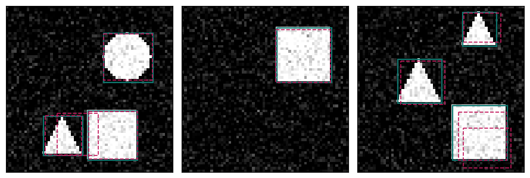

```
бірюзові суцільні — істина, малинові пунктирні — anchor-free детектор після NMS
```

```python
predictions = predict_free(free_plain_model, test_images[:3])

figure, axes = plt.subplots(1, 3, figsize=(9, 3.2))
for axis, (image, truth_boxes, _labels), (boxes, scores, _class_id) in zip(
        axes, test_set[:3], predictions):
    axis.imshow(image, cmap="gray", vmin=0, vmax=1)
    for box in truth_boxes:
        axis.add_patch(plt.Rectangle((box[0], box[1]), box[2] - box[0], box[3] - box[1],
                                     fill=False, edgecolor="#0f766e", linewidth=1.6))
    chosen = scores >= 0.3
    picked_boxes, picked_scores = boxes[chosen], scores[chosen]
    if len(picked_boxes):
        keep = nms(picked_boxes, picked_scores, 0.5)
        for position in keep.tolist():
            box = picked_boxes[position]
            axis.add_patch(plt.Rectangle((box[0], box[1]), box[2] - box[0],
                                         box[3] - box[1], fill=False,
                                         edgecolor="#c2185b", linewidth=1.2,
                                         linestyle="--"))
    axis.set_xticks([]); axis.set_yticks([])
plt.tight_layout()
plt.show()
print("бірюзові суцільні — істина, малинові пунктирні — anchor-free детектор після NMS")
```

## 12 · Підсумок зошита

```python
print("Що поміряно:")
print()
print("  бінарних рішень на сцену                 %d" % decisions)
print("  позитивних із них                        %.2f (%.3f %%)"
      % (positive_per_scene, 100 * positive_per_scene / decisions))
print("  на один позитивний негативних            %.0f"
      % ((decisions - positive_per_scene) / positive_per_scene))
print("  вибірка 1 : 3 викидає                    %.1f %% рішень сцени"
      % (100 * (decisions - kept_total) / decisions))
print()
print("  фон у втраті свіжої мережі               %.2f %%"
      % (100 * background_loss / total_loss))
print("  легкі негативні у втраті, γ = 0          %.1f %%" % contribution[0.0][2])
print("  легкі негативні у втраті, γ = 2          %.1f %%" % contribution[2.0][2])
print("  предмети у втраті, γ = 0 → γ = 2         %.1f %% → %.1f %%"
      % (contribution[0.0][0], contribution[2.0][0]))
print()
print("  втрата на першому кроці, зсув 0          %.2f" % numbers[("нульовий", 0.0)])
print("  те саме зі зсувом π = 0.01               %.2f" % numbers[("π = 0.01", 0.0)])
print("  focal, зсув 0 → π = 0.01                 %.2f → %.2f"
      % (numbers[("нульовий", 2.0)], numbers[("π = 0.01", 2.0)]))
print()
print("  mAP@0.5 при γ = 0                        %.4f (розкид %.4f)"
      % (float(np.mean(gamma_scores[0.0])),
         max(gamma_scores[0.0]) - min(gamma_scores[0.0])))
print("  mAP@0.5 при γ = 1                        %.4f" % float(np.mean(gamma_scores[1.0])))
print("  mAP@0.5 при γ = 2                        %.4f (розкид %.4f)"
      % (float(np.mean(gamma_scores[2.0])),
         max(gamma_scores[2.0]) - min(gamma_scores[2.0])))
print("  mAP@0.5 при γ = 5                        %.4f" % float(np.mean(gamma_scores[5.0])))
print()
print("  anchor-free mAP@0.5                      %.4f" % float(np.mean(free_plain_scores)))
print("  параметрів у голові, якірна → free       %d → %d"
      % (anchor_parameters - body_parameters, free_parameters - body_parameters))
print("  centerness: без гілки → з множником      %.4f → %.4f"
      % (float(np.mean(free_plain_scores)), float(np.mean(with_centerness))))
print()
print("  retinanet_resnet50_fpn                   %d параметрів" % count_parameters(retina))
print("  fcos_resnet50_fpn                        %d параметрів" % count_parameters(fcos))
print("  хребет у них однаковий                   %d" % count_parameters(retina.backbone))
print()
print("  навчань усього                           %d" % len(training_seconds))
print("  середній час одного навчання             %.1f с" % float(np.mean(training_seconds)))
print("  разом на навчання                        %.0f с" % sum(training_seconds))
```

```
Що поміряно:

  бінарних рішень на сцену                 576
  позитивних із них                        4.05 (0.703 %)
  на один позитивний негативних            141
  вибірка 1 : 3 викидає                    97.2 % рішень сцени

  фон у втраті свіжої мережі               99.72 %
  легкі негативні у втраті, γ = 0          57.7 %
  легкі негативні у втраті, γ = 2          1.2 %
  предмети у втраті, γ = 0 → γ = 2         15.8 % → 78.9 %

  втрата на першому кроці, зсув 0          72.19
  те саме зі зсувом π = 0.01               2.25
  focal, зсув 0 → π = 0.01                 19.70 → 1.15

  mAP@0.5 при γ = 0                        0.7549 (розкид 0.1420)
  mAP@0.5 при γ = 1                        0.7817
  mAP@0.5 при γ = 2                        0.8610 (розкид 0.0444)
  mAP@0.5 при γ = 5                        0.5656

  anchor-free mAP@0.5                      0.9187
  параметрів у голові, якірна → free       12117 → 4039
  centerness: без гілки → з множником      0.9187 → 0.7938

  retinanet_resnet50_fpn                   34068119 параметрів
  fcos_resnet50_fpn                        32322720 параметрів
  хребет у них однаковий                   27376704

  навчань усього                           18
  середній час одного навчання             9.6 с
  разом на навчання                        173 с
```

## Завдання

### 🟢 Рівень 1 — База

Побудуй графік focal loss від `p` для `γ` = 0, 0.5, 1, 2, 5 на одних осях. Познач на ньому точку `p = 0.9` і підпиши, у скільки разів `γ = 2` тлумить цей приклад.

**Зроблено, якщо:** графік побудовано, і ти можеш назвати `γ`, при якому приклад із `p = 0.7` стає тихішим за приклад із `p = 0.1` при `γ = 0`.

### 🟡 Рівень 2 — Плюс

Прожени `first_step_loss` для `π` = 0.5, 0.1, 0.05, 0.01, 0.001 і побудуй графік «втрата на першому кроці проти `π`». Поясни словами, чому крива не спадає нескінченно: що починає рости, коли `π` стає надто малим.

**Зроблено, якщо:** графік побудовано, мінімум знайдено чисельно, і пояснення спирається на два доданки втрати окремо (фон і предмети), а не на загальну суму.

### 🔴 Рівень 3 — Виклик

Реалізуй свою anchor-free голову з нуля (можна взяти нашу за зразок, але напиши зіставлення сам — із центральною вибіркою `radius = 1.5` з розділу 9) і порівняй `mAP@0.5` та `mAP@0.5:0.95` з якірною головою **при однаковому бюджеті**: те саме тіло, та сама кількість епох, ті самі три зерна.

**Зроблено, якщо:** чотири числа надруковано в одній таблиці разом із розкидом по зернах, і ти можеш сказати, чи різниця більша за розкид — і що саме змінила центральна вибірка порівняно з простим правилом «усередині рамки».